# Startup COVID era analysis

Author

Babak Fi Foo

```python
import sys
sys.path.append('../src/')

import loader
import numpy as np
import pandas as pd
from datetime import datetime as dt

from IPython.display import Markdown, display

import seaborn as sns
import matplotlib.pyplot as plt
import matplotlib.dates as mdates

from arch.unitroot.unitroot import DFGLS
from statsmodels.graphics.tsaplots import plot_acf, plot_pacf
import statsmodels.api as sm
from statsmodels.tsa.arima.model import ARIMA, ARIMAResults

plt.rcParams['font.family'] = 'Adobe Caslon Pro'
plt.rcParams['font.size'] = 12

import warnings
warnings.filterwarnings("ignore")

print("setting up the data...")

macro_data = loader.startupMacro()
data = macro_data.load()
```

```
setting up the data...
```

# 1 Testing for unit root

The whole duration of the data is used for this test statistics to avoid any potential bias.

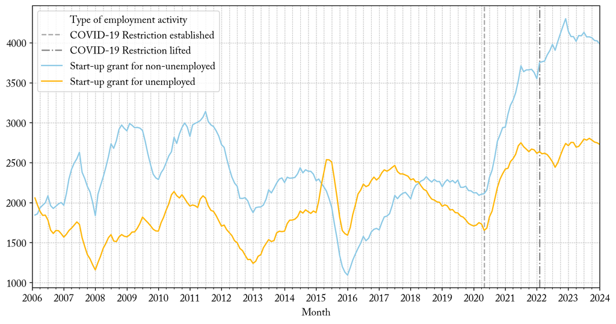

```python
plt.figure(figsize=(12, 6))
plt.grid(True, which="both", ls="--", lw=0.5)

COVID = dt.strptime("2020-05-01", '%Y-%m-%d')
NORMAL = dt.strptime("2022-02-01", '%Y-%m-%d')

ax = plt.gca()
ax.xaxis.set_major_locator(mdates.YearLocator())
ax.xaxis.set_minor_locator(mdates.MonthLocator(interval=3))

plt.xlim(
    dt.strptime("2006-01-01", '%Y-%m-%d'),
    dt.strptime("2024-01-01", '%Y-%m-%d')
    )

plt.axvline(x=COVID, color='#AAAAAA', linestyle='--',  label='COVID-19 Restriction established', lw=1.5)
plt.axvline(x=NORMAL, color='#888888', linestyle='-.',  label='COVID-19 Restriction lifted', lw=1.5)
sns.lineplot(data=data.loc[:,[
    "Start-up grant for non-unemployed",
    "Start-up grant for unemployed"
]], palette=["#8ecae6","#ffb703"], dashes=False, ax=ax)


plt.show()
```

The DF-GLS test for unit-root indicates that both series are affected by unit-root at their 7th lag, and cannot reject the existance of the unit-root.

```python
col1 = "Start-up grant for non-unemployed"
test_1 = DFGLS(data[col1], max_lags=12, method="bic").summary()

print(test_1.as_text())
```

```
      Dickey-Fuller GLS Results
=====================================
Test Statistic                 -0.625
P-value                         0.462
Lags                                7
-------------------------------------

Trend: Constant
Critical Values: -2.66 (1%), -2.04 (5%), -1.72 (10%)
Null Hypothesis: The process contains a unit root.
Alternative Hypothesis: The process is weakly stationary.
```

```python
col2 = "Start-up grant for unemployed"
test_2 = DFGLS(data[col2], max_lags=12, method="bic").summary()
print(test_2.as_text())
```

```
      Dickey-Fuller GLS Results
=====================================
Test Statistic                 -1.443
P-value                         0.144
Lags                                7
-------------------------------------

Trend: Constant
Critical Values: -2.66 (1%), -2.04 (5%), -1.72 (10%)
Null Hypothesis: The process contains a unit root.
Alternative Hypothesis: The process is weakly stationary.
```

First differencing the series resulted in a stationary series. This means that the unit-root is not cause by trend, nor drift. Hence the plausable datagenerating process is:

$$y_{t} = \alpha_0 + \alpha_1 y_{t-1} + \varepsilon_{t}$$

Therefore further uni-variate time-series analysis could be implemented.

```python
col1 = "Start-up grant for non-unemployed"
test_1 = DFGLS(data[col1].diff().dropna(), max_lags=12, method="bic").summary()
print(test_1.as_text())
```

```
      Dickey-Fuller GLS Results
=====================================
Test Statistic                 -4.039
P-value                         0.000
Lags                                6
-------------------------------------

Trend: Constant
Critical Values: -2.66 (1%), -2.04 (5%), -1.72 (10%)
Null Hypothesis: The process contains a unit root.
Alternative Hypothesis: The process is weakly stationary.
```

```python
col2 = "Start-up grant for unemployed"
test_2 = DFGLS(data[col2].diff().dropna(), max_lags=12, method="bic").summary()
print(test_2.as_text())
```

```
      Dickey-Fuller GLS Results
=====================================
Test Statistic                 -1.990
P-value                         0.046
Lags                                6
-------------------------------------

Trend: Constant
Critical Values: -2.66 (1%), -2.04 (5%), -1.72 (10%)
Null Hypothesis: The process contains a unit root.
Alternative Hypothesis: The process is weakly stationary.
```